# Animal behavior analysis: Comparing healthy and vestibular syndrome rats

Author

Irving Ernesto Quezada Ramírez

# Background

The study of animal behavior under controlled experimental conditions offers a unique window to explore how physical variables can reveal crucial aspects of adaptation and behavioral phenomena under different conditions. This approach allows us to analyze how biological alterations, such as those of the vestibular system, affect both locomotion dynamics and environmental sensing, as well as behavioral adaptation in static and dynamic environments.

Physical variables, such as displacement velocity, trajectory patterns, and efficiency in performing temporo-spatial learning tasks (i.e., when and where a resource is delivered), offer a precise and quantitative measure of how subjects adapt their behavior under specific biological conditions. This multidimensional approach not only broadens our understanding of the mechanisms underlying behavioral adaptations and phenomena but could also have significant implications for developing therapeutic interventions and improving quality of life in cases of neurological disorders.

In this context, our study explores the use of physical variables to identify distinctive patterns of behavior between healthy subjects and those with vestibular syndrome (VS). This approach provides a more comprehensive view of the complexities in the integration of locomotion and spatio-temporal learning.

## Objective

To compare behavioral dynamics in healthy Wistar rats and rats with vestibular syndrome by analyzing associated physical variables, such as displacement velocity, trajectory patterns, and location density, under reinforcement programs contingent on the organisms’ displacement (FD/VD 100cm), using an expanded experimental chamber for water delivery.

# Method

## Subjects

Four 4-5 month old female Wistar rats, experimentally naive, two healthy (H) and two with vestibular syndrome (VS), water-deprived for 23 hours.

## Apparatus

Functional Space Densification Apparatus (FSDA), 100 x 100 x 40 cm with uniform black walls and floor.

## Procedure

# The Analysis

## Basic set-up: Loading data

For ease of execution, once we clone the GitHub repository with this code, we have to add the corresponding base folder as the working directory for R to use. This is done in the initial part of the code after the imports, the `setwd()` function. This is an ad-hoc solution and *shouldn’t* be used like that for a quarto document, but to not waste any more time on it let’s keep it this way.

This will make accessing the data a little bit easier along with letting RStudio know where the project’s files are located.

```r
# Load required libraries
library(tidyverse)
library(readr)

project_dir <- "C:/Users/irvin/OneDrive/Escritorio/Ratas"
setwd(project_dir)

# Function to read and preprocess data
read_and_preprocess <- function(file_path) {
  # Specify column types explicitly
  col_types <- cols(
    Time = col_double(),
    X = col_double(),
    Y = col_double(),
    .default = col_skip()  # Skip all other columns
  )

  data <- read_csv(file_path,
                   skip = 12,
                   col_types = col_types,
                   show_col_types = FALSE) %>%
    select(Time, X, Y) %>%
    mutate(
      file = basename(file_path),
      rat = substr(basename(file_path), 1, 2),
      condition = if_else(str_detect(basename(file_path), "DV"), "DV", "DF"),
      session = as.numeric(str_extract(basename(file_path), "(?<=s)\\d+")),
      health_status = if_else(str_detect(file_path, "Síndrome Vestibular"), "Enferma", "Sana")
    )
  return(data)
}

# Get file paths
s3_files <- list.files("Datos/Sanas/S3", full.names = TRUE, pattern = "*.csv")
s4_files <- list.files("Datos/Sanas/S4", full.names = TRUE, pattern = "*.csv")
s2_files <- list.files("Datos/Síndrome Vestibular/S2", full.names = TRUE, pattern = "*.csv")
s5_files <- list.files("Datos/Síndrome Vestibular/S5", full.names = TRUE, pattern = "*.csv")

all_files <- c(s3_files, s4_files, s2_files, s5_files)

# Read and combine all files
all_data <- map_df(all_files, ~read_and_preprocess(.))
```

## EDA: First Exploratory Data Analysis

Before we do any further analysis of this data, we have to take care of the exploratory data analysis. This is, taking care of outliers, NaNs, get a *feel* of how the data is structured and maybe some hints towards what we’ll eventually model.

### Summary statistics of the original data

```r
# Load the psych package for detailed summary statistics
library(psych)

# Select only numeric columns
numeric_data <- all_data %>% select_if(is.numeric)

# Detailed summary statistics using the psych package
detailed_summary <- describe(numeric_data)
detailed_summary
```

|  | vars | n | mean | sd | median | trimmed | mad | min | max | range | skew | kurtosis | se |
| --- | --- | --- | --- | --- | --- | --- | --- | --- | --- | --- | --- | --- | --- |
| Time | 1 | 1160365 | 600.69569 | 346.29667 | 600.96100 | 600.79955 | 444.62877 | 0.0000000 | 1199.996 | 1199.9960 | -0.0019962015 | -1.199950 | 0.32147782 |
| X | 2 | 1160365 | 49.75163 | 30.50130 | 46.27151 | 49.38966 | 40.53763 | 0.1912046 | 100.000 | 99.8088 | 0.1641666234 | -1.212562 | 0.02831529 |
| Y | 3 | 1160365 | 49.64784 | 29.59940 | 46.75573 | 49.67968 | 37.91382 | 0.0000000 | 100.000 | 100.0000 | 0.0712466127 | -1.140433 | 0.02747803 |
| session | 4 | 1160365 | 20.49096 | 11.56023 | 20.00000 | 20.48846 | 14.82600 | 1.0000000 | 40.000 | 39.0000 | 0.0007960552 | -1.204528 | 0.01073172 |

1. Time:
   - Mean: 600.70
   - Range: 0 to 1200
   - Standard Deviation: 346.30
   - The symmetric distribution (mean ≈ median) suggests consistent timing across sessions, with no significant skewness.
2. X and Y Coordinates:
   - Mean: ~49.7 for both X and Y
   - Range: 0 to 100
   - Standard Deviation: ~30 for both coordinates
   - Coordinates are evenly distributed within the 100x100 experimental chamber, indicating that rats explored the entire space.
3. Session:
   - Mean: 20.49
   - Range: 1 to 40
   - Standard Deviation: 11.56
   - The even distribution of sessions (median = 20) suggests that data was collected uniformly across sessions.
4. Distributions:
   - Skewness: Close to 0 for all variables, indicating symmetric distributions.
   - Kurtosis: Slightly negative (~-1.2), suggesting flatter-than-normal distributions, which is typical for exploratory behavior data.

Sweet! Now let’s see if we have any missing data:

```r
# Check for NaNs in the dataset
nan_summary <- all_data %>%
  summarise(across(everything(), ~ sum(is.na(.))))

print("Summary of NaNs in the dataset:")
```

```
[1] "Summary of NaNs in the dataset:"
```

```r
print(nan_summary)
```

```
# A tibble: 1 × 8
   Time     X     Y  file   rat condition session health_status
  <int> <int> <int> <int> <int>     <int>   <int>         <int>
1     0     0     0     0     0         0       0             0
```

```r
# Calculate displacement, velocity, and acceleration
all_data <- all_data %>%
  group_by(rat, session, condition) %>%
  arrange(Time) %>%
  mutate(
    # Time difference
    delta_Time = Time - lag(Time)
  ) %>%
  ungroup()

# Remove rows with NA values (first row of each group due to lag)
all_data <- all_data %>% filter(!is.na(delta_Time))
```

After we’ve got our data, we can take the summary statistics once again:

```r
# Select only numeric columns for summary statistics
numeric_data_processed <- all_data$delta_Time

# Detailed summary statistics using the psych package
detailed_summary_processed <- describe(numeric_data_processed)
detailed_summary_processed
```

|  | vars | n | mean | sd | median | trimmed | mad | min | max | range | skew | kurtosis | se |
| --- | --- | --- | --- | --- | --- | --- | --- | --- | --- | --- | --- | --- | --- |
| X1 | 1 | 1160205 | 0.1654751 | 0.01564136 | 0.164 | 0.1645214 | 0.0014826 | 0.159 | 14.612 | 14.453 | 688.1716 | 628101 | 1.452136e-05 |

```r
all_data %>% arrange(desc(delta_Time))
```

| Time | X | Y | file | rat | condition | session | health_status | delta_Time |
| --- | --- | --- | --- | --- | --- | --- | --- | --- |
| 770.202 | 0.1912046 | 12.9770992 | S4s8DF100.csv | S4 | DF | 8 | Sana | 14.612 |
| 627.318 | 7.2657744 | 8.3969466 | S4s7DF100.csv | S4 | DF | 7 | Sana | 2.812 |
| 1076.026 | 6.6921606 | 6.2977099 | S4s3DF100.csv | S4 | DF | 3 | Sana | 1.479 |
| 520.563 | 2.4856597 | 83.5877863 | S2s8DF100.csv | S2 | DF | 8 | Enferma | 0.987 |
| 868.632 | 0.1912046 | 39.5038168 | S2s6DF100.csv | S2 | DF | 6 | Enferma | 0.970 |
| 433.922 | 6.6921606 | 7.6335878 | S4s5DF100.csv | S4 | DF | 5 | Sana | 0.818 |
| 27.154 | 0.1912046 | 16.2213741 | S4s9DF100.csv | S4 | DF | 9 | Sana | 0.816 |
| 0.729 | 51.6252390 | 42.5572519 | S2s31DF100.csv | S2 | DF | 31 | Enferma | 0.729 |
| 0.727 | 88.7189293 | 94.8473282 | S3s6DV100.csv | S3 | DV | 6 | Sana | 0.727 |
| 0.727 | 94.4550669 | 92.5572519 | S4s24DF100.csv | S4 | DF | 24 | Sana | 0.727 |

[output cut: 9990 more lines]

Here we have only one occurrence of an extremely long period of time, then we have a 2.8 seconds delta and finally a 1.47 delta, with every other delta staying under that.

### Identifying measurement errors with time_delta

Let’s make a plot to get a better hang of what’s going on:

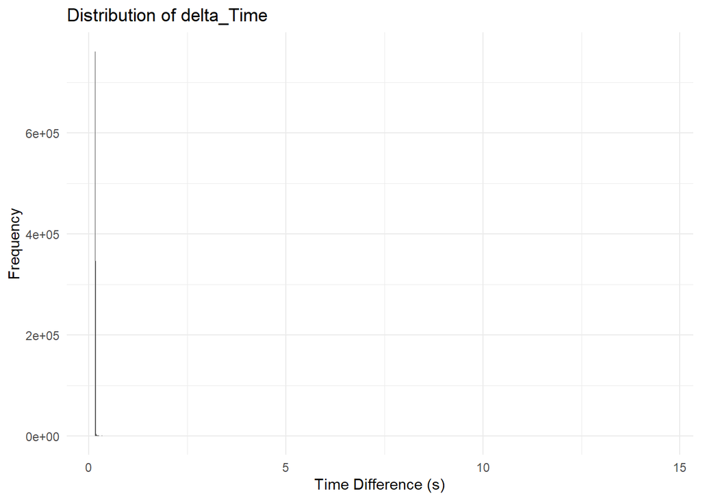

```r
# Plot histogram of delta_Time
ggplot(all_data, aes(x = delta_Time)) +
  geom_histogram(binwidth = 0.01) +
  labs(title = "Distribution of delta_Time",
       x = "Time Difference (s)",
       y = "Frequency") +
  theme_minimal()
```

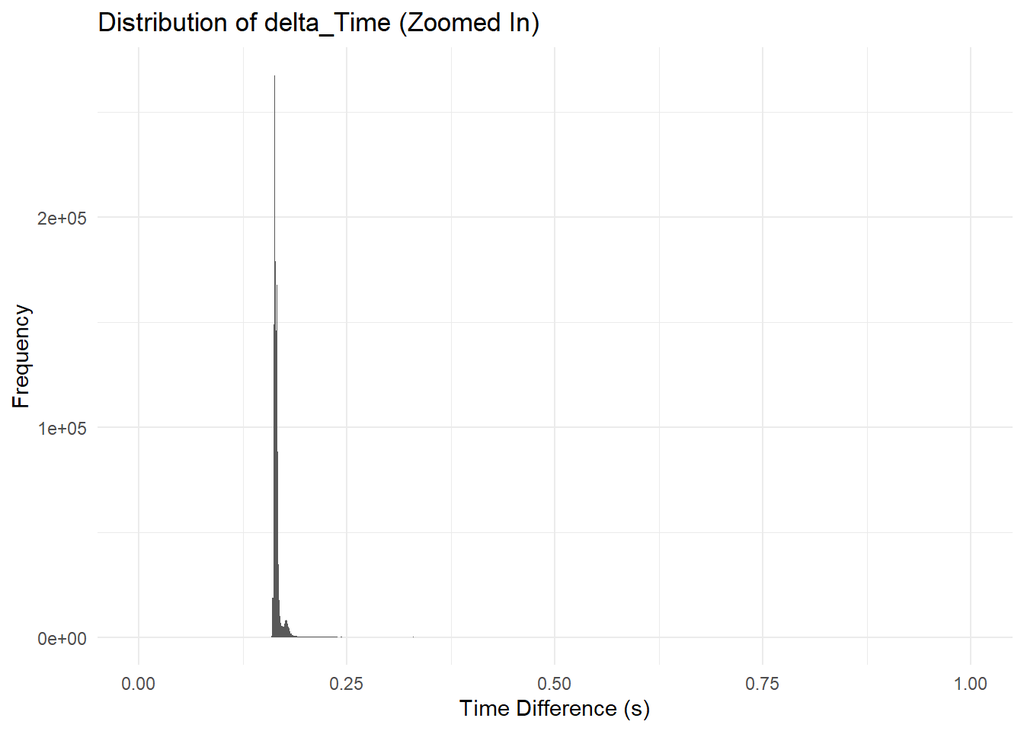

```r
# Zoom in on the majority of the data
ggplot(all_data, aes(x = delta_Time)) +
  geom_histogram(binwidth = 0.001) +
  labs(title = "Distribution of delta_Time (Zoomed In)",
       x = "Time Difference (s)",
       y = "Frequency") +
  xlim(0, 1) +  # Focus on values below 1 second
  theme_minimal()
```

Well, that was something to expect! For the most part we have a large concentration around 0.17 just like the summary statistics told us so. The peak is prominent and anything outside of ~0.18 is pretty much nothing. Necessarily, anything over 1 second is a measurement error.

IMPORTANT NOTE: After checking the interactive table of data, it doesn’t skew at all/hurt the analysis the fact that we have those few outliers, and although it isn’t healthy per-se to have them in the dataset, we can proceed as normal as if they weren’t there.

### Derived kinematic variables: Displacement, velocity & acceleration

Now that we have a more nuanced understanding of the data, its composition & limitations, we should start calculating relevant kinematic variables:

```r
# Calculate kinematic variables (displacement, velocity, acceleration) with components
all_data <- all_data %>%
  group_by(rat, session, condition) %>%
  arrange(Time) %>%
  mutate(
    # Displacement components (X and Y)
    displacement_X = X - lag(X),
    displacement_Y = Y - lag(Y),
    # Displacement magnitude
    displacement_magnitude = sqrt(displacement_X^2 + displacement_Y^2),

    # Velocity components (X and Y)
    velocity_X = displacement_X / delta_Time,
    velocity_Y = displacement_Y / delta_Time,
    # Velocity magnitude
    velocity_magnitude = sqrt(velocity_X^2 + velocity_Y^2),

    # Acceleration components (X and Y)
    acceleration_X = (velocity_X - lag(velocity_X)) / delta_Time,
    acceleration_Y = (velocity_Y - lag(velocity_Y)) / delta_Time,
    # Acceleration magnitude
    acceleration_magnitude = sqrt(acceleration_X^2 + acceleration_Y^2)
  ) %>%
  ungroup()

# Remove rows with NA values (first row of each group due to lag)
all_data <- all_data %>% filter(!is.na(displacement_magnitude))

# Summary statistics of kinematic variables with components
kinematic_summary <- all_data %>%
  select(displacement_magnitude, velocity_magnitude, acceleration_magnitude,
         displacement_X, displacement_Y, velocity_X, velocity_Y, acceleration_X, acceleration_Y) %>%
  describe()
print(kinematic_summary)
```

```
                       vars       n  mean     sd median      min     max
displacement_magnitude    1 1160045  3.17   4.64   0.85     0.00   95.58
velocity_magnitude        2 1160045 19.16  28.04   5.18     0.00  590.02
acceleration_magnitude    3 1159885 92.67 146.03  35.69     0.00 6502.87
displacement_X            4 1160045  0.00   4.11   0.00   -50.86   51.63
displacement_Y            5 1160045  0.00   3.83   0.00   -80.34   83.40
velocity_X                6 1160045  0.00  24.84   0.00  -306.39  314.79
velocity_Y                7 1160045  0.00  23.16   0.00  -482.85  505.37
acceleration_X            8 1159885  0.00 124.50   0.00 -3706.91 3710.91
acceleration_Y            9 1159885  0.00 120.05   0.00 -5768.56 6067.11
                          range skew kurtosis   se
displacement_magnitude    95.58 2.05     5.49 0.00
velocity_magnitude       590.02 2.05     5.46 0.03
acceleration_magnitude  6502.87 4.26    44.74 0.14
displacement_X           102.49 0.00     7.95 0.00
displacement_Y           163.74 0.52    11.26 0.00
velocity_X               621.18 0.00     7.97 0.02
velocity_Y               988.22 0.51    11.18 0.02
acceleration_X          7417.82 0.01    27.79 0.12
acceleration_Y         11835.67 0.49    60.23 0.11
```

### **Displacement**

- **Displacement Magnitude**:
  - The mean displacement magnitude is **3.17 cm**, with a standard deviation of **4.64 cm**.
  - The median displacement magnitude is **0.85 cm**, indicating that most movements are relatively small, but there are occasional larger displacements (up to **95.58 cm**).
  - The positive skewness (**2.05**) and high kurtosis (**5.49**) suggest that the distribution is right-skewed, with a few extreme values.
- **Displacement Components (X and Y)**:
  - Both X and Y displacements have a mean of **0.00 cm**, indicating symmetry in movement along both axes.
  - The standard deviations for X and Y displacements are **4.11 cm** and **3.83 cm**, respectively, showing similar variability.
  - The skewness for X displacement is **0.00**, while for Y displacement, it is **0.52**, suggesting slightly asymmetric movement in the Y direction.

### **Velocity**

- **Velocity Magnitude**:
  - The mean velocity magnitude is **19.16 cm/s**, with a standard deviation of **28.04 cm/s**.
  - The median velocity magnitude is **5.18 cm/s**, indicating that most movements are slow, but there are occasional bursts of high velocity (up to **590.02 cm/s**).
  - The positive skewness (**2.05**) and high kurtosis (**5.46**) suggest a right-skewed distribution with extreme values.
- **Velocity Components (X and Y)**:
  - Both X and Y velocities have a mean of **0.00 cm/s**, indicating balanced movement along both axes.
  - The standard deviations for X and Y velocities are **24.84 cm/s** and **23.16 cm/s**, respectively, showing similar variability.
  - The skewness for X velocity is **0.00**, while for Y velocity, it is **0.51**, suggesting slightly asymmetric movement in the Y direction.

### **Acceleration**

- **Acceleration Magnitude**:
  - The mean acceleration magnitude is **92.67 cm/s²**, with a standard deviation of **146.03 cm/s²**.
  - The median acceleration magnitude is **35.69 cm/s²**, indicating that most accelerations are moderate, but there are occasional extreme values (up to **6502.87 cm/s²**).
  - The positive skewness (**4.26**) and extremely high kurtosis (**44.75**) suggest a highly right-skewed distribution with many extreme values.
- **Acceleration Components (X and Y)**:
  - Both X and Y accelerations have a mean close to **0.00 cm/s²**, indicating balanced acceleration along both axes.
  - The standard deviations for X and Y accelerations are **124.51 cm/s²** and **120.05 cm/s²**, respectively, showing similar variability.
  - The skewness for X acceleration is **0.01**, while for Y acceleration, it is **0.49**, suggesting slightly asymmetric acceleration in the Y direction.

### **Key Observations**

1. **Movement Patterns**:
   - The rats exhibit small, frequent movements (as indicated by the median displacement and velocity magnitudes) but occasionally make large, rapid movements (as indicated by the maximum values).
   - The symmetry in X and Y displacements and velocities suggests balanced exploration of the experimental chamber.
2. **Extreme Values**:
   - The presence of extreme values in displacement, velocity, and acceleration magnitudes suggests occasional bursts of activity, which could be related to specific behavioral events (e.g., reaching for water or reacting to stimuli).
3. **Measurement Errors**:
   - The high kurtosis and skewness values, particularly for acceleration, highlight the presence of extreme values that may require further investigation or filtering.
4. **Implications for Analysis**:
   - The derived kinematic variables provide a robust foundation for comparing movement patterns between healthy and vestibular syndrome rats.
   - Future analyses could focus on identifying specific movement patterns (e.g., turning, freezing) and their relationship to the experimental conditions (FD vs. VD).

### **Next Steps**

- **Filtering Outliers**:
  - Consider applying thresholds to filter out extreme values in displacement, velocity, and acceleration that may represent measurement errors or biologically implausible movements.
- **Behavioral Segmentation**:
  - Segment the data into distinct behavioral states (e.g., resting, exploring, running) based on kinematic variables.
- **Group Comparisons**:
  - Compare the kinematic variables between healthy and vestibular syndrome rats to identify differences in movement patterns and adaptation strategies.
- **Visualization**:
  - Create visualizations (e.g., heatmaps, trajectory plots) to explore spatial and temporal patterns in the data.

By leveraging these kinematic variables, we can gain deeper insights into the behavioral dynamics of the rats and how they adapt to the experimental conditions, particularly in the context of vestibular syndrome.

By plotting what we have

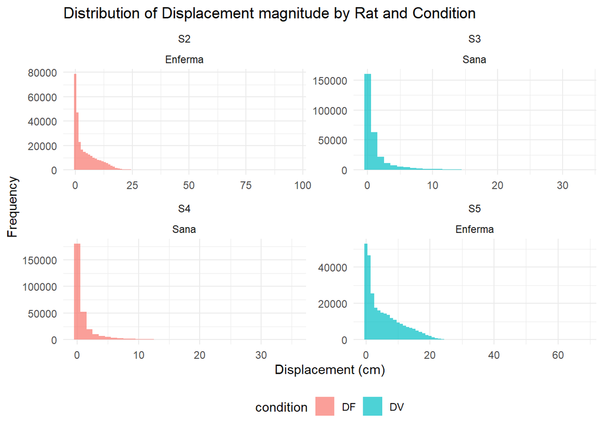

```r
ggplot(all_data, aes(x = displacement_magnitude, fill = condition)) +
  geom_histogram(binwidth = 1, alpha = 0.7) +
  facet_wrap(~ rat + health_status, scales = "free") +
  labs(
    title = "Distribution of Displacement magnitude by Rat and Condition",
    x = "Displacement (cm)",
    y = "Frequency"
  ) +
  theme_minimal() +
  theme(legend.position = "bottom")
```

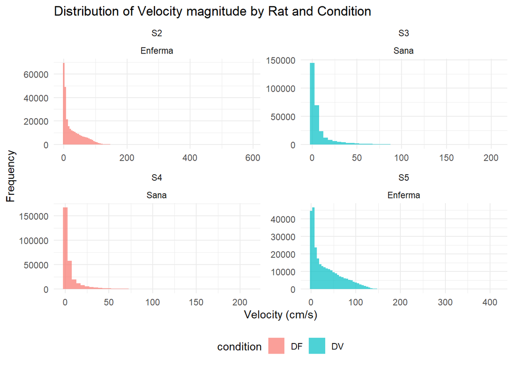

```r
ggplot(all_data, aes(x = velocity_magnitude, fill = condition)) +
  geom_histogram(binwidth = 5, alpha = 0.7) +
  facet_wrap(~ rat + health_status, scales = "free") +
  labs(
    title = "Distribution of Velocity magnitude by Rat and Condition",
    x = "Velocity (cm/s)",
    y = "Frequency"
  ) +
  theme_minimal() +
  theme(legend.position = "bottom")
```

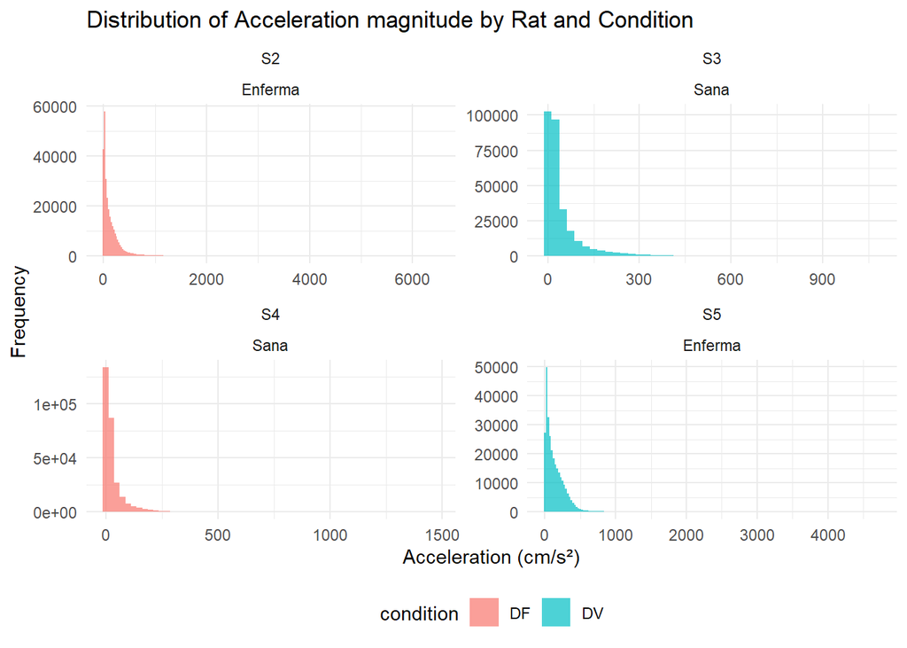

```r
ggplot(all_data, aes(x = acceleration_magnitude, fill = condition)) +
  geom_histogram(binwidth = 25, alpha = 0.7) +
  facet_wrap(~ rat + health_status, scales = "free") +
  labs(
    title = "Distribution of Acceleration magnitude by Rat and Condition",
    x = "Acceleration (cm/s²)",
    y = "Frequency"
  ) +
  theme_minimal() +
  theme(legend.position = "bottom")
```

Having a rat moving at 1 m/s would be insane. Having a rat with an acceleration of 10 m/s^2 would be even crazier, and by looking at the graphs we could use these thresholds to filter out outliers, HOWEVER, it’d be better if we were to use the IQR to get rid of them!:

```r
# Function to filter outliers using IQR
filter_outliers_iqr <- function(data, variable) {
  data %>%
    group_by(condition, health_status) %>%
    mutate(
      Q1 = quantile(!!sym(variable), 0.25, na.rm = TRUE),
      Q3 = quantile(!!sym(variable), 0.75, na.rm = TRUE),
      IQR = Q3 - Q1,
      lower_bound = Q1 - 1.5 * IQR,
      upper_bound = Q3 + 1.5 * IQR
    ) %>%
    filter(!!sym(variable) >= lower_bound & !!sym(variable) <= upper_bound) %>%
    ungroup() %>%
    select(-Q1, -Q3, -IQR, -lower_bound, -upper_bound)
}

# Apply IQR filtering to displacement, velocity, and acceleration
filtered_data <- all_data %>%
  filter_outliers_iqr("displacement_magnitude") %>%
  filter_outliers_iqr("velocity_magnitude") %>%
  filter_outliers_iqr("acceleration_magnitude")

# Check the summary statistics after filtering
filtered_summary <- filtered_data %>%
  select(displacement_magnitude, velocity_magnitude, acceleration_magnitude) %>%
  describe()
print(filtered_summary)
```

```
                       vars      n  mean    sd median trimmed   mad min    max
displacement_magnitude    1 972219  2.68  4.17   0.57    1.71  0.85   0  20.96
velocity_magnitude        2 972219 16.18 25.21   3.51   10.35  5.21   0 124.25
acceleration_magnitude    3 972219 69.42 92.87  25.25   49.74 27.30   0 458.23
                        range skew kurtosis   se
displacement_magnitude  20.96 1.90     2.83 0.00
velocity_magnitude     124.25 1.90     2.83 0.03
acceleration_magnitude 458.23 1.77     2.43 0.09
```

and to make sure we’re looking at how the distributions look like, let’s use density graphs:

## Plotting the distributions

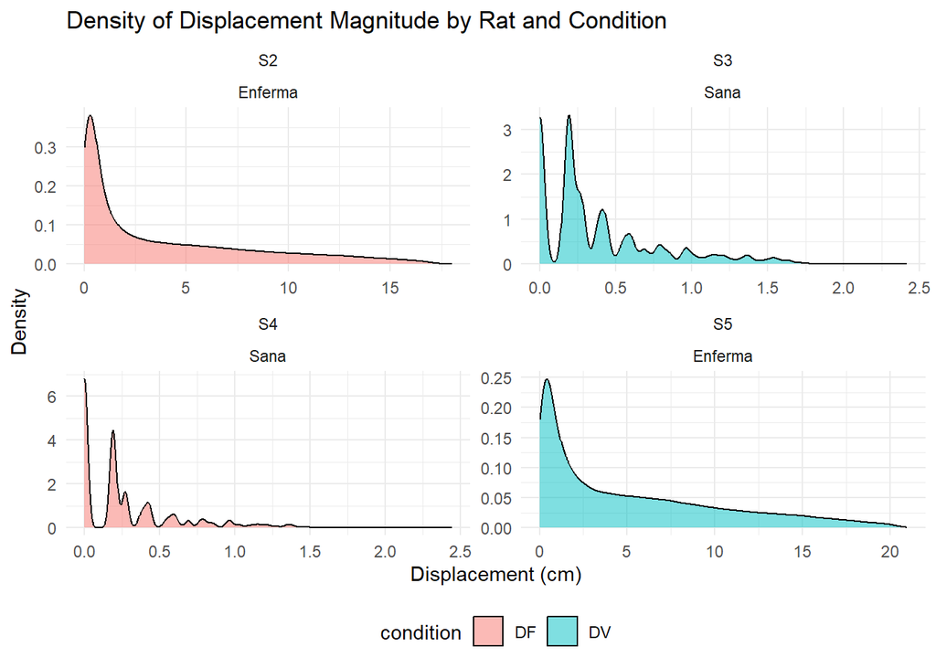

```r
ggplot(filtered_data, aes(x = displacement_magnitude, fill = condition)) +
  geom_density(alpha = 0.5) +
  facet_wrap(~ rat + health_status, scales = "free") +
  labs(
    title = "Density of Displacement Magnitude by Rat and Condition",
    x = "Displacement (cm)",
    y = "Density"
  ) +
  theme_minimal() +
  theme(legend.position = "bottom")
```

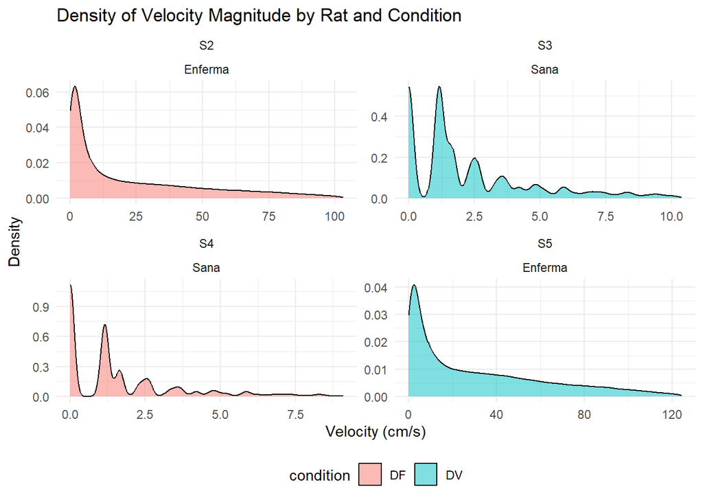

```r
ggplot(filtered_data, aes(x = velocity_magnitude, fill = condition)) +
  geom_density(alpha = 0.5) +
  facet_wrap(~ rat + health_status, scales = "free") +
  labs(
    title = "Density of Velocity Magnitude by Rat and Condition",
    x = "Velocity (cm/s)",
    y = "Density"
  ) +
  theme_minimal() +
  theme(legend.position = "bottom")
```

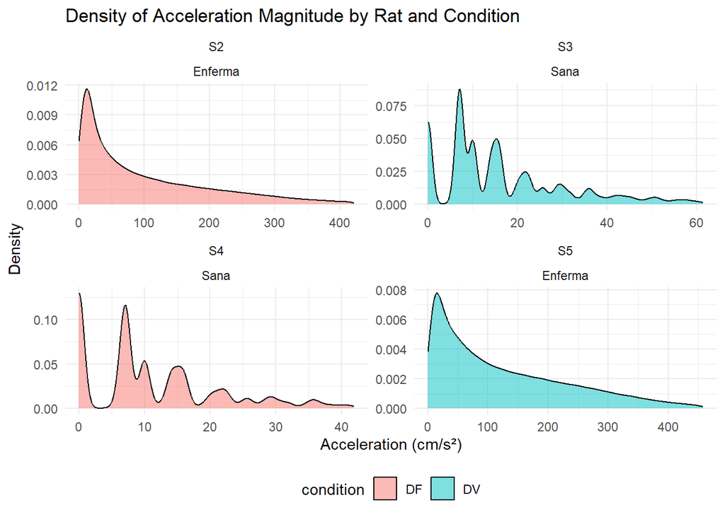

```r
ggplot(filtered_data, aes(x = acceleration_magnitude, fill = condition)) +
  geom_density(alpha = 0.5) +
  facet_wrap(~ rat + health_status, scales = "free") +
  labs(
    title = "Density of Acceleration Magnitude by Rat and Condition",
    x = "Acceleration (cm/s²)",
    y = "Density"
  ) +
  theme_minimal() +
  theme(legend.position = "bottom")
```

I’ll let you take a look yourself, but there are clear differences between sick rats and healthy rats in every kinematic variable. For sick & healthy rats, whether we have DF or DV it’s clear which one is healthy and which one isn’t. In particular, for healthy rats we see wave-like distribution graphs with peaks at specific displacements, velocities & accelerations whereas for sick rats we see continuous distributions without additional peaks.

## Statistical analysis

```r
# Load required libraries for statistical analysis
library(car)         # For Levene's Test
library(lme4)        # For Linear Mixed-Effects Models
library(lmerTest)    # For p-values in mixed models
library(emmeans)     # For post-hoc comparisons
library(ggpubr)      # For publication-ready plots
```

### Descriptive statistics

```r
# Summary statistics by health_status and condition
summary_stats <- filtered_data %>%
  group_by(health_status, condition) %>%
  summarise(
    count = n(),
    mean_displacement = mean(displacement_magnitude, na.rm = TRUE),
    sd_displacement = sd(displacement_magnitude, na.rm = TRUE),
    mean_velocity = mean(velocity_magnitude, na.rm = TRUE),
    sd_velocity = sd(velocity_magnitude, na.rm = TRUE),
    mean_acceleration = mean(acceleration_magnitude, na.rm = TRUE),
    sd_acceleration = sd(acceleration_magnitude, na.rm = TRUE)
  )

print(summary_stats)
```

```
# A tibble: 4 × 9
# Groups:   health_status [2]
  health_status condition  count mean_displacement sd_displacement mean_velocity
  <chr>         <chr>      <int>             <dbl>           <dbl>         <dbl>
1 Enferma       DF        265068             3.83            4.32          23.1
2 Enferma       DV        280156             5.17            5.15          31.3
3 Sana          DF        213645             0.267           0.324          1.61
4 Sana          DV        213350             0.375           0.393          2.27
# ℹ 3 more variables: sd_velocity <dbl>, mean_acceleration <dbl>,
#   sd_acceleration <dbl>
```

I already tried doing LMMs & log transformations to no avail, if you were wondering. So it’s time to search an alternative approach in hopes of finding statistical proof of the differences between healthy & sick rats (besides the graphs).

# Additional analysis I had forgotten about

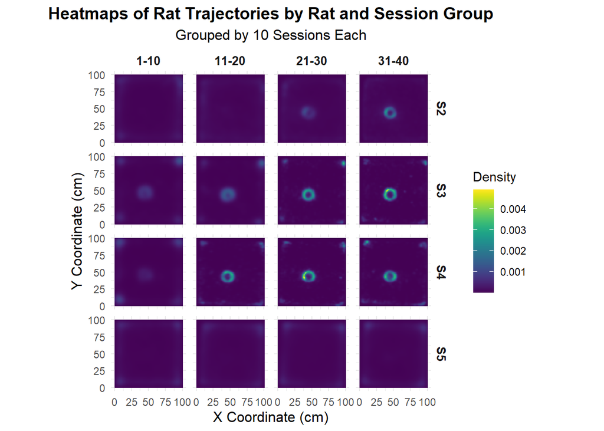

```r
# Load required libraries
library(ggplot2)
library(dplyr)
library(viridis)
library(gridExtra)

# Ensure 'filtered_data' has 'session_group' as defined earlier
filtered_data <- filtered_data %>%
  mutate(session_group = ceiling(session / 10))  # Changed from /5 to /10

# Optional: Label session groups for better readability
filtered_data <- filtered_data %>%
  mutate(session_group_label = case_when(
    session_group == 1 ~ "1-10",
    session_group == 2 ~ "11-20",
    session_group == 3 ~ "21-30",
    session_group == 4 ~ "31-40",
    TRUE ~ paste0((session_group - 1) * 10 + 1, "-", session_group * 10)
  ))

# Define the order of session groups
filtered_data$session_group_label <- factor(filtered_data$session_group_label,
                                           levels = c("1-10", "11-20", "21-30", "31-40"))

# Create the heatmap using facet_grid
heatmap_plot <- ggplot(filtered_data, aes(x = X, y = Y)) +
  stat_density2d(aes(fill = ..density..), geom = "raster", contour = FALSE) +
  scale_fill_viridis(name = "Density") +
  coord_fixed() +
  facet_grid(rat ~ session_group_label) +  # Updated facets to reflect new labels
  labs(
    title = "Heatmaps of Rat Trajectories by Rat and Session Group",
    subtitle = "Grouped by 10 Sessions Each",
    x = "X Coordinate (cm)",
    y = "Y Coordinate (cm)"
  ) +
  theme_minimal() +
  theme(
    strip.text = element_text(size = 10, face = "bold"),
    axis.title = element_text(size = 12),
    plot.title = element_text(size = 14, face = "bold", hjust = 0.5),
    plot.subtitle = element_text(size = 12, hjust = 0.5)
  )

# Display the heatmap grid
print(heatmap_plot)
```

From this plot we can see that for healthy rats (S3 & S4) they seem to optimize their movement patterns by staying near the center forming a ring-like shape. Meanwhile, for the DF methodology, the sick rats try to optimize, althouugh not as well and for the DV methodology there doesn’t appear to be any succesful optimization by the rat.

# Exporting data

```r
# Export filtered_data as a CSV file
write.csv(filtered_data, file = "filtered_data.csv", row.names = FALSE)
```